# Large seedling models for Tony & Kevin

Kathleen Stutzman

2024-01-25

Hidden below is code for importing the data set and log transforming variables. The best model (lowest AIC & using lrtest) is presented below, model fit checked, and pairwise comparison for Treatment Type.

I did create and test models without treatment type, but they always have higher AIC and worse model fit that those with (probably due to the control category…)

##### Variables investigated:

- **Treat_Type** - treatment type
- **PIRI** - pitch pine seedling count (10m<sup>2</sup>)
- **SO** - shrub oak seedling count (10m<sup>2</sup>)
- **other** - other seedling count (10m<sup>2</sup>)
- **BA_HA** - basal area per hectare
- **BA_piri** - pitch pine basal area per hectare
- **Mineral** - exposed mineral soil (1m<sup>2</sup>)
- **avgLD** - average leaf litter depth (1m<sup>2</sup>)
- **Veg_Total** - total understory plant cover (1m<sup>2</sup>)
- **TFT** - time between treatment and sampling (used as an offset)
- **Site/Plot_No** - random effect of plots within sites

*Variables are log transformed (l. or _l)*

# Pitch Pine Regeneration

#### Testing zero inflation

```r
tapply(ls.all3$PIRI, ls.all3$Region, summary)
```

```
## $ALB
##    Min. 1st Qu.  Median    Mean 3rd Qu.    Max.
## 0.00000 0.00000 0.00000 0.01639 0.00000 1.00000
##
## $LI
##    Min. 1st Qu.  Median    Mean 3rd Qu.    Max.
##  0.0000  0.0000  0.0000  0.0137  0.0000  1.0000
##
## $MA
##    Min. 1st Qu.  Median    Mean 3rd Qu.    Max.
##     0.0     0.0     0.0     0.5     0.0    14.0
##
## $ME
##    Min. 1st Qu.  Median    Mean 3rd Qu.    Max.
##       0       0       0       0       0       0
##
## $NH
##    Min. 1st Qu.  Median    Mean 3rd Qu.    Max.
##   0.000   0.000   0.000   0.266   0.000   9.000
```

```r
# no PIRI in ME
tapply(ls.all3$PIRI, ls.all3$Treat_Type, summary)
```

```
## $Control
##    Min. 1st Qu.  Median    Mean 3rd Qu.    Max.
## 0.00000 0.00000 0.00000 0.04274 0.00000 3.00000
##
## $FallRx
##    Min. 1st Qu.  Median    Mean 3rd Qu.    Max.
## 0.00000 0.00000 0.00000 0.09804 0.00000 4.00000
##
## $Harvest
##    Min. 1st Qu.  Median    Mean 3rd Qu.    Max.
##   0.000   0.000   0.000   1.304   1.250  14.000
##
## $MowRx
##    Min. 1st Qu.  Median    Mean 3rd Qu.    Max.
##  0.0000  0.0000  0.0000  0.1103  0.0000  9.0000
##
## $SpringRx
##    Min. 1st Qu.  Median    Mean 3rd Qu.    Max.
## 0.00000 0.00000 0.00000 0.02299 0.00000 1.00000
```

#### Best large seedling pitch pine model

```r
ls.m19 <- glmmTMB(PIRI ~ Treat_Type + avgLD_l + offset(l.TFT) + (1|Site/Plot_No),
                 data = ls.all3,
                 family = nbinom1)
summary(ls.m19)
```

```
##  Family: nbinom1  ( log )
## Formula:
## PIRI ~ Treat_Type + avgLD_l + offset(l.TFT) + (1 | Site/Plot_No)
## Data: ls.all3
##
##      AIC      BIC   logLik deviance df.resid
##    282.4    320.3   -132.2    264.4      489
##
## Random effects:
##
## Conditional model:
##  Groups       Name        Variance  Std.Dev.
##  Plot_No:Site (Intercept) 7.864e-09 8.868e-05
##  Site         (Intercept) 8.389e+00 2.896e+00
## Number of obs: 498, groups:  Plot_No:Site, 498; Site, 47
##
## Dispersion parameter for nbinom1 family (): 1.84
##
## Conditional model:
##                    Estimate Std. Error z value Pr(>|z|)
## (Intercept)         -8.0011     1.8849  -4.245 2.19e-05 ***
## Treat_TypeFallRx     2.8946     1.8244   1.587 0.112610
## Treat_TypeHarvest    5.8075     1.9747   2.941 0.003271 **
## Treat_TypeMowRx      2.2997     1.7665   1.302 0.192968
## Treat_TypeSpringRx   2.9793     1.9726   1.510 0.130956
## avgLD_l             -0.9013     0.2489  -3.622 0.000293 ***
## ---
## Signif. codes:  0 '***' 0.001 '**' 0.01 '*' 0.05 '.' 0.1 ' ' 1
```

#### Check model fit

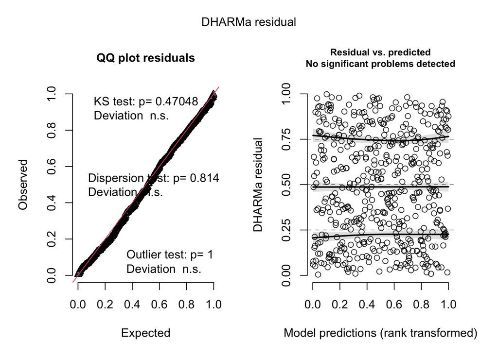

```r
ls.m19_sr <- simulateResiduals(ls.m19, n = 1000, plot = TRUE) #passes
```

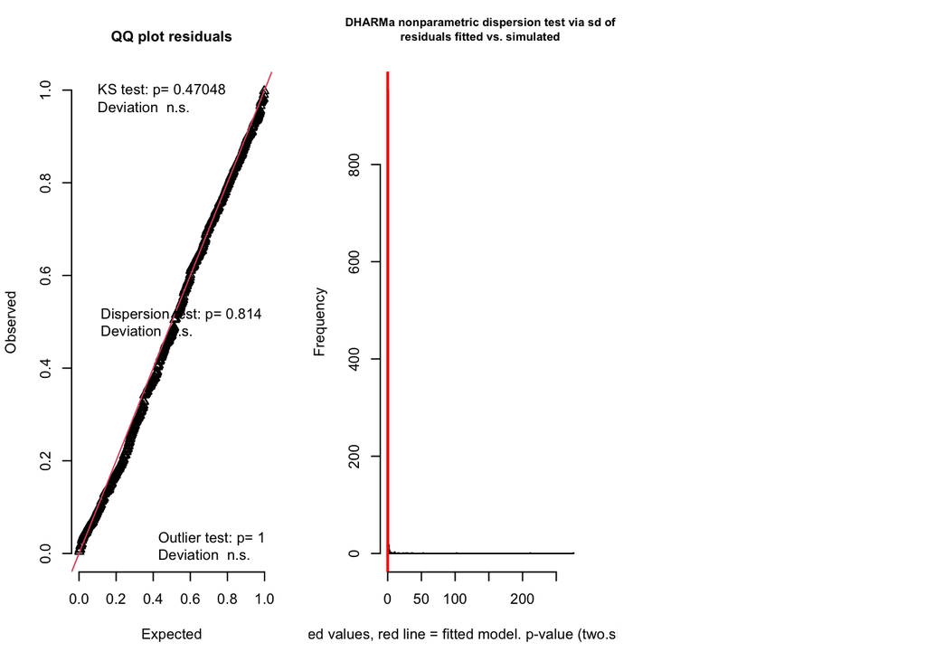

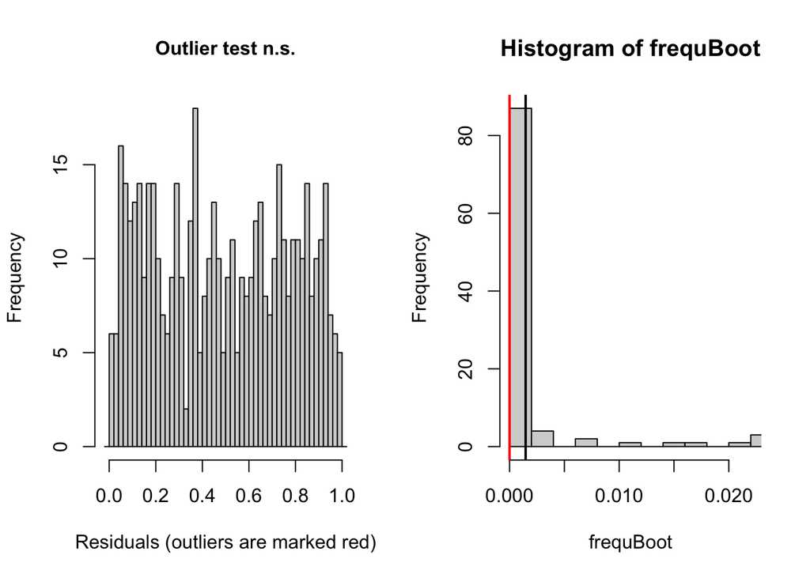

```
## $uniformity
##
##  Asymptotic one-sample Kolmogorov-Smirnov test
##
## data:  simulationOutput$scaledResiduals
## D = 0.037938, p-value = 0.4705
## alternative hypothesis: two-sided
##
##
## $dispersion
##
##  DHARMa nonparametric dispersion test via sd of residuals fitted vs.
##  simulated
##
## data:  simulationOutput
## dispersion = 0.0031118, p-value = 0.814
## alternative hypothesis: two.sided
##
##
## $outliers
##
##  DHARMa bootstrapped outlier test
##
## data:  simulationOutput
## outliers at both margin(s) = 0, observations = 498, p-value = 1
## alternative hypothesis: two.sided
##  percent confidence interval:
##  0.00000000 0.02113454
## sample estimates:
## outlier frequency (expected: 0.00146586345381526 )
##                                                  0
```

```
## $uniformity
##
##  Asymptotic one-sample Kolmogorov-Smirnov test
##
## data:  simulationOutput$scaledResiduals
## D = 0.037938, p-value = 0.4705
## alternative hypothesis: two-sided
##
##
## $dispersion
##
##  DHARMa nonparametric dispersion test via sd of residuals fitted vs.
##  simulated
##
## data:  simulationOutput
## dispersion = 0.0031118, p-value = 0.814
## alternative hypothesis: two.sided
##
##
## $outliers
##
##  DHARMa bootstrapped outlier test
##
## data:  simulationOutput
## outliers at both margin(s) = 0, observations = 498, p-value = 1
## alternative hypothesis: two.sided
##  percent confidence interval:
##  0.00000000 0.02113454
## sample estimates:
## outlier frequency (expected: 0.00146586345381526 )
##                                                  0
```

```r
testResiduals(ls.m19_sr) #passes
```

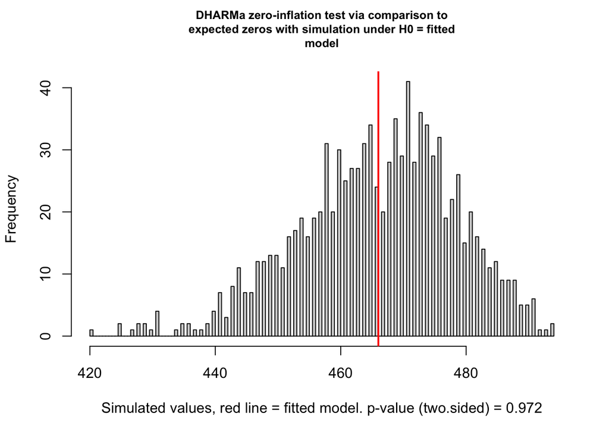

```
##
##  DHARMa zero-inflation test via comparison to expected zeros with
##  simulation under H0 = fitted model
##
## data:  simulationOutput
## ratioObsSim = 0.99996, p-value = 0.972
## alternative hypothesis: two.sided
```

```r
testZeroInflation(ls.m19_sr) #passes
```

Had quantile issues, resolved by using nbinom instead of poisson; zero inflation by region doesn’t improve the model - still works/passes tests but higher AIC

#### Pairwise with treatment type

###### These are really rates due to the offset for time

```r
emmeans(ls.m19, specs = pairwise ~ Treat_Type, adjust = 'Tukey', type = 'response')
```

```
## $emmeans
##  Treat_Type response       SE  df asymp.LCL asymp.UCL
##  Control    0.000518 0.000953 Inf  1.41e-05    0.0191
##  FallRx     0.009362 0.016220 Inf  3.14e-04    0.2793
##  Harvest    0.172374 0.280718 Inf  7.08e-03    4.1946
##  MowRx      0.005164 0.008595 Inf  1.98e-04    0.1348
##  SpringRx   0.010190 0.017281 Inf  3.67e-04    0.2829
##
## Confidence level used: 0.95
## Intervals are back-transformed from the log scale
##
## $contrasts
##  contrast             ratio       SE  df null z.ratio p.value
##  Control / FallRx    0.0553  0.10093 Inf    1  -1.587  0.5060
##  Control / Harvest   0.0030  0.00593 Inf    1  -2.941  0.0271
##  Control / MowRx     0.1003  0.17716 Inf    1  -1.302  0.6901
##  Control / SpringRx  0.0508  0.10026 Inf    1  -1.510  0.5557
##  FallRx / Harvest    0.0543  0.10307 Inf    1  -1.535  0.5395
##  FallRx / MowRx      1.8129  3.06288 Inf    1   0.352  0.9967
##  FallRx / SpringRx   0.9187  1.74321 Inf    1  -0.045  1.0000
##  Harvest / MowRx    33.3770 61.40768 Inf    1   1.907  0.3137
##  Harvest / SpringRx 16.9152 33.56315 Inf    1   1.425  0.6112
##  MowRx / SpringRx    0.5068  0.93049 Inf    1  -0.370  0.9960
##
## P value adjustment: tukey method for comparing a family of 5 estimates
## Tests are performed on the log scale
```

###### Only harvest is significantly different than contol

#### Graph pitch pine models

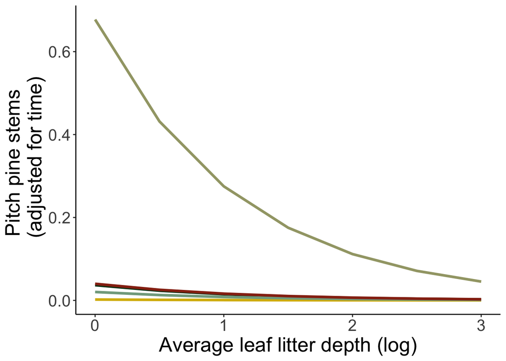

# Shrub Oak Regeneration

This includes QUIL (scrub oak) & QUPR (dwarf chinkapin oak)

#### Large seedling shrub oak model

- Poisson, nbinom, genpois, & compois models all fail due to underdispersion. Some have issues with zero inflation as well. Gaussian dispersion also fails due to issues with uniformity.

```r
tapply(ls.all3$Shrub_Oak, ls.all3$Region, summary)
```

```
## $ALB
##    Min. 1st Qu.  Median    Mean 3rd Qu.    Max.
##    0.00    0.00   10.50   18.29   34.00   68.00
##
## $LI
##    Min. 1st Qu.  Median    Mean 3rd Qu.    Max.
##   0.000   0.000   1.000   4.452   6.000  30.000
##
## $MA
##    Min. 1st Qu.  Median    Mean 3rd Qu.    Max.
##    0.00    0.00    8.00   14.49   19.00   73.00
##
## $ME
##    Min. 1st Qu.  Median    Mean 3rd Qu.    Max.
##    0.00    8.00   13.00   16.42   23.50   47.00
##
## $NH
##    Min. 1st Qu.  Median    Mean 3rd Qu.    Max.
##    0.00    6.25   17.00   19.14   27.00   74.00
```

```r
tapply(ls.all3$Shrub_Oak, ls.all3$Treat_Type, summary)
```

```
## $Control
##    Min. 1st Qu.  Median    Mean 3rd Qu.    Max.
##   0.000   0.000   2.000   5.684   9.000  47.000
##
## $FallRx
##    Min. 1st Qu.  Median    Mean 3rd Qu.    Max.
##    0.00    2.25   13.00   16.08   25.00   67.00
##
## $Harvest
##    Min. 1st Qu.  Median    Mean 3rd Qu.    Max.
##   0.000   0.000   1.500   5.768  10.000  32.000
##
## $MowRx
##    Min. 1st Qu.  Median    Mean 3rd Qu.    Max.
##    0.00   13.00   26.00   27.68   40.00   74.00
##
## $SpringRx
##    Min. 1st Qu.  Median    Mean 3rd Qu.    Max.
##     0.0     0.0     7.0    12.6    17.0    61.0
```

##### These are my best models, all are underdispersed

#### Best Model

```r
so.ls5 <- glmmTMB(Shrub_Oak ~ Treat_Type + l.PIRI + l.other + l.Veg_Total + offset(l.TFT) + (1|Site/Plot_No),
                 data = ls.all3,
                 ziformula = ~1,
                 family = genpois)
summary(so.ls5)
```

```
##  Family: genpois  ( log )
## Formula:
## Shrub_Oak ~ Treat_Type + l.PIRI + l.other + l.Veg_Total + offset(l.TFT) +
##     (1 | Site/Plot_No)
## Zero inflation:             ~1
## Data: ls.all3
##
##      AIC      BIC   logLik deviance df.resid
##   3267.3   3317.8  -1621.6   3243.3      486
##
## Random effects:
##
## Conditional model:
##  Groups       Name        Variance Std.Dev.
##  Plot_No:Site (Intercept) 0.08187  0.2861
##  Site         (Intercept) 0.97499  0.9874
## Number of obs: 498, groups:  Plot_No:Site, 498; Site, 47
##
## Dispersion parameter for genpois family (): 8.01
##
## Conditional model:
##                    Estimate Std. Error z value Pr(>|z|)
## (Intercept)        -2.94791    0.42709  -6.902 5.12e-12 ***
## Treat_TypeFallRx    3.20832    0.48348   6.636 3.22e-11 ***
## Treat_TypeHarvest   2.40848    0.55615   4.331 1.49e-05 ***
## Treat_TypeMowRx     4.32943    0.44516   9.726  < 2e-16 ***
## Treat_TypeSpringRx  3.65532    0.48789   7.492 6.78e-14 ***
## l.PIRI             -0.38785    0.19308  -2.009   0.0446 *
## l.other            -0.11699    0.05036  -2.323   0.0202 *
## l.Veg_Total         0.17110    0.07100   2.410   0.0160 *
## ---
## Signif. codes:  0 '***' 0.001 '**' 0.01 '*' 0.05 '.' 0.1 ' ' 1
##
## Zero-inflation model:
##             Estimate Std. Error z value Pr(>|z|)
## (Intercept)  -2.6709     0.3736  -7.149 8.73e-13 ***
## ---
## Signif. codes:  0 '***' 0.001 '**' 0.01 '*' 0.05 '.' 0.1 ' ' 1
```

#### Check model fit

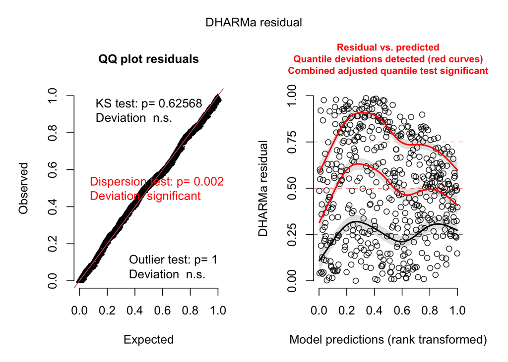

```r
so.ls5_sr <- simulateResiduals(so.ls5, n = 1000, plot = T)
```

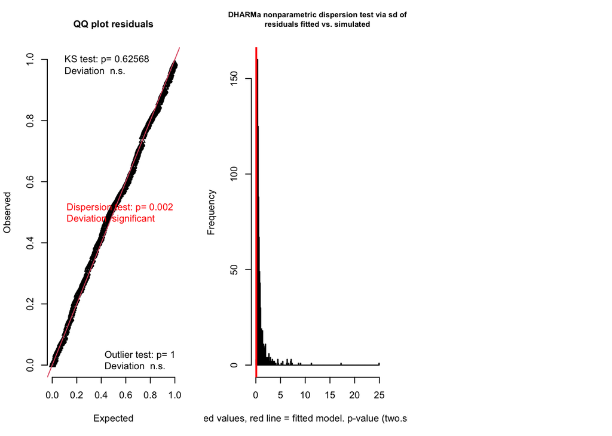

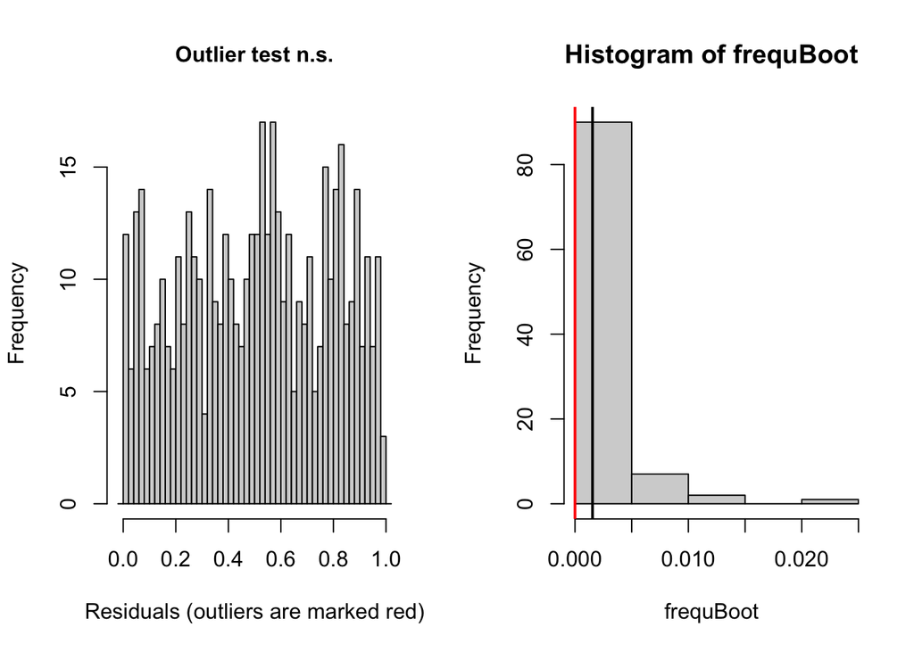

```
## $uniformity
##
##  Asymptotic one-sample Kolmogorov-Smirnov test
##
## data:  simulationOutput$scaledResiduals
## D = 0.033648, p-value = 0.6257
## alternative hypothesis: two-sided
##
##
## $dispersion
##
##  DHARMa nonparametric dispersion test via sd of residuals fitted vs.
##  simulated
##
## data:  simulationOutput
## dispersion = 0.10303, p-value = 0.002
## alternative hypothesis: two.sided
##
##
## $outliers
##
##  DHARMa bootstrapped outlier test
##
## data:  simulationOutput
## outliers at both margin(s) = 0, observations = 498, p-value = 1
## alternative hypothesis: two.sided
##  percent confidence interval:
##  0.000000000 0.009086345
## sample estimates:
## outlier frequency (expected: 0.00154618473895582 )
##                                                  0
```

```
## $uniformity
##
##  Asymptotic one-sample Kolmogorov-Smirnov test
##
## data:  simulationOutput$scaledResiduals
## D = 0.033648, p-value = 0.6257
## alternative hypothesis: two-sided
##
##
## $dispersion
##
##  DHARMa nonparametric dispersion test via sd of residuals fitted vs.
##  simulated
##
## data:  simulationOutput
## dispersion = 0.10303, p-value = 0.002
## alternative hypothesis: two.sided
##
##
## $outliers
##
##  DHARMa bootstrapped outlier test
##
## data:  simulationOutput
## outliers at both margin(s) = 0, observations = 498, p-value = 1
## alternative hypothesis: two.sided
##  percent confidence interval:
##  0.000000000 0.009086345
## sample estimates:
## outlier frequency (expected: 0.00154618473895582 )
##                                                  0
```

```r
testResiduals(so.ls5_sr)
```

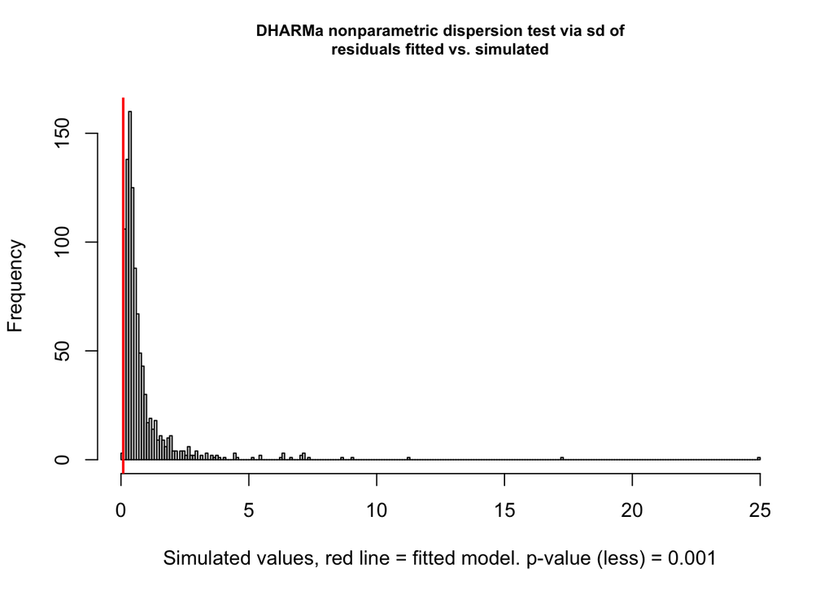

```
##
##  DHARMa nonparametric dispersion test via sd of residuals fitted vs.
##  simulated
##
## data:  simulationOutput
## dispersion = 0.10303, p-value = 0.001
## alternative hypothesis: less
```

```r
testDispersion(so.ls5_sr, alternative = "less")
```

```r
check_collinearity(so.ls5) #low
```

```
## # Check for Multicollinearity
##
## * conditional component:
##
## Low Correlation
##
##         Term  VIF   VIF 95% CI Increased SE Tolerance Tolerance 95% CI
##   Treat_Type 1.04 [1.00, 1.43]         1.02      0.96     [0.70, 1.00]
##       l.PIRI 1.02 [1.00, 2.41]         1.01      0.98     [0.42, 1.00]
##      l.other 1.02 [1.00, 3.06]         1.01      0.98     [0.33, 1.00]
##  l.Veg_Total 1.03 [1.00, 1.68]         1.01      0.97     [0.60, 1.00]
```

#### Pairwise with treatment type

```r
emmeans(so.ls5, specs = pairwise ~ Treat_Type, adjust = 'Tukey', type = 'response')
```

[output not shown]

#### Graph model

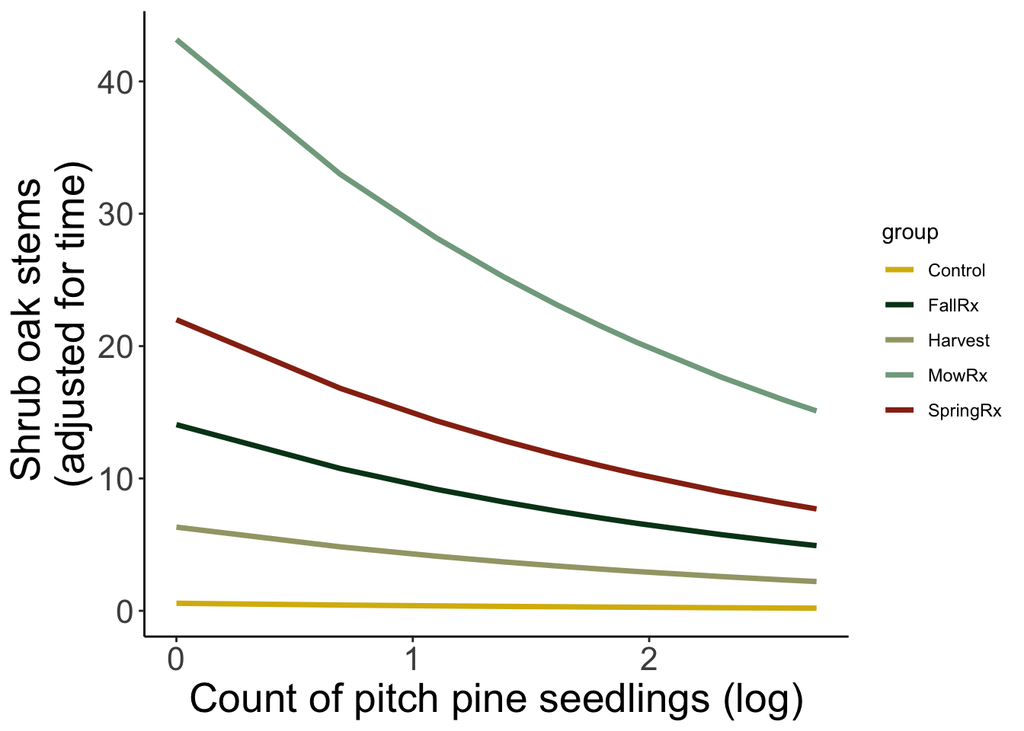

```r
# SO LS -------------------
ls.s1 <- ggpredict(so.ls5, terms = c("l.PIRI", "Treat_Type"))


ggplot(ls.s1, aes(x, predicted, color = group))+
  geom_line(linewidth = 1.25) +
  scale_color_manual(values = c("#D8B70A",  "#02401B", "#A2A475", "#81A88D", "#972D15"))+
  theme_classic()+
  theme(panel.background = element_blank()) +
  theme(axis.text = element_text(size = 16), axis.title = element_text(size = 20))+
  labs(x = "Count of pitch pine seedlings (log)",
       y = "Shrub oak stems \n(adjusted for time)")
```

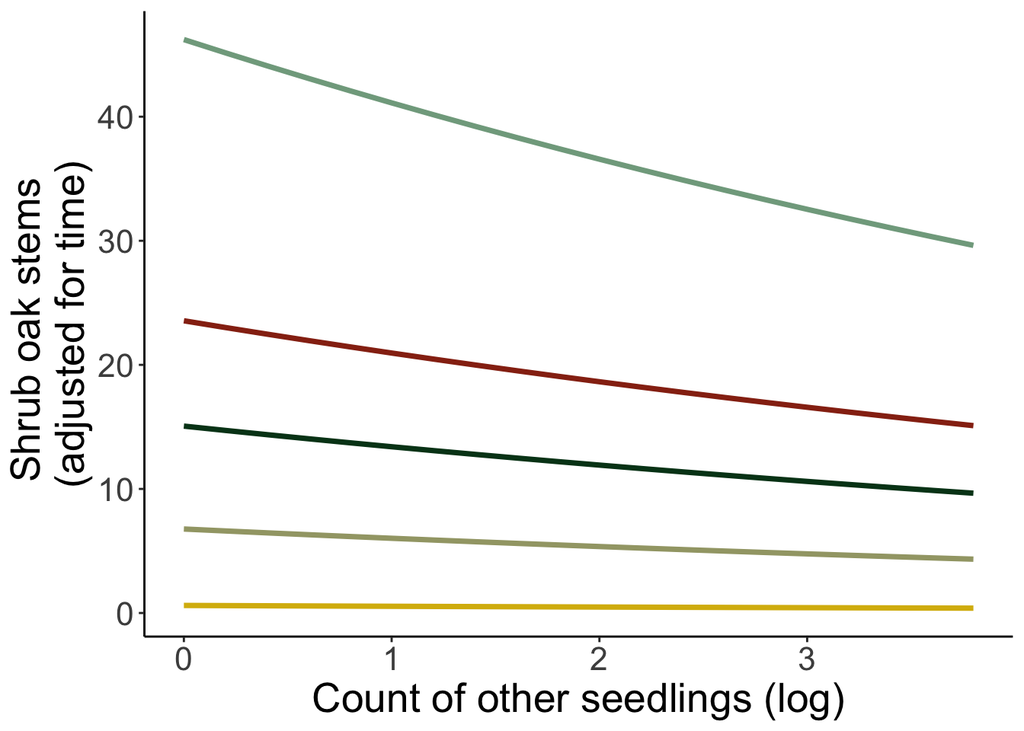

```r
#ggsave(filename = "LS_PIRI_avgld.tiff", path = "Plots/PIRI_GLMM", width = 7, height = 5, device = "tiff", dpi = 700)


ls.s2 <- ggpredict(so.ls5, terms = c("l.other", "Treat_Type"))


ggplot(ls.s2, aes(x, predicted, color = group))+
  geom_line(linewidth = 1.25, show.legend = FALSE) +
  scale_color_manual(values = c("#D8B70A",  "#02401B", "#A2A475", "#81A88D", "#972D15"))+
  theme_classic()+
  theme(panel.background = element_blank()) +
  theme(axis.text = element_text(size = 16), axis.title = element_text(size = 20))+
  labs(x = "Count of other seedlings (log)",
       y = "Shrub oak stems \n(adjusted for time)")
```

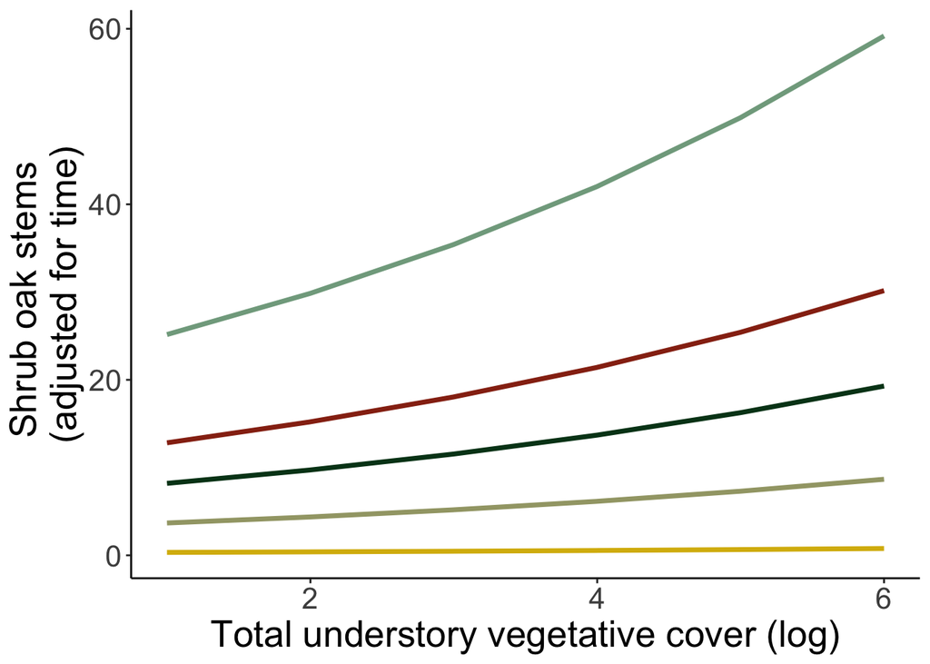

```r
# -------------------
ls.s3 <- ggpredict(so.ls5, terms = c("l.Veg_Total", "Treat_Type"))


ggplot(ls.s3, aes(x, predicted, color = group))+
  geom_line(linewidth = 1.25, show.legend = FALSE) +
  scale_color_manual(values = c("#D8B70A",  "#02401B", "#A2A475", "#81A88D", "#972D15"))+
  theme_classic()+
  theme(panel.background = element_blank()) +
  theme(axis.text = element_text(size = 16), axis.title = element_text(size = 20))+
  labs(x = "Total understory vegetative cover (log)",
       y = "Shrub oak stems \n(adjusted for time)")
```

```r
# low collinearity but still gives me a little pause..
```

### Interesting - it is always Mowing -> SpringRx -> Fall Rx -> Harvest -> Control